# Final Project Report

### Guiding Question

If England soccer clubs play against Spain soccer clubs one by one, which country’s teams are more like to win?

```r
library(readr)
library(tidyverse)
library(ggplot2)
library(DataComputing)
library(tidyr)
```

### Become acquainted with your data sources:

I found the data tables from data.world and datahub on the internet.

Data table 1: https://data.world/chas/2018-2019-premier-league-matches

Data table 2: https://datahub.io/sports-data/spanish-la-liga#resource-season-1819

Chas Peacock collected the data 1.

Datahub community collected the data 2.

Both data tables were collected last year.

A case represents a single match result. There are 380 cases in each table.

Variables I plan to use: HomeTeam AwayTeam

```
                     FTR: Full-Time-Result

                     FTHG: Full time home goal

                     FTAG: Full time away goal

                     HS: Home shots

                     AS: Away shots
```

These variables begin with a capital letter because they are from the original data. All the following varibles I created begin with lowercase letter and their meanings are clear.

Other notes: Since England soccer league and Spain soccer league have the same number of teams(20), there are also equal number of games(10) in each round, they would have the same cases. Accordingly, it is reasonable to investigate winning probability from those two leagues.

### Data Access

```r
England = read.csv("2018-2019.csv",header = TRUE) # access the England data.
England %>%
  head(10) # briefly view the data table
```

|  | Div | Date | HomeTeam | AwayTeam | FTHG | FTAG | FTR | HTHG | HTAG | HTR | Referee | HS | AS | HST | AST | HF | AF | HC | AC | HY | AY | HR | AR |
| --- | --- | --- | --- | --- | --- | --- | --- | --- | --- | --- | --- | --- | --- | --- | --- | --- | --- | --- | --- | --- | --- | --- | --- |
| 1 | E0 | 10/8/18 | Man United | Leicester | 2 | 1 | H | 1 | 0 | H | A Marriner | 8 | 13 | 6 | 4 | 11 | 8 | 2 | 5 | 2 | 1 | 0 | 0 |
| 2 | E0 | 11/8/18 | Bournemouth | Cardiff | 2 | 0 | H | 1 | 0 | H | K Friend | 12 | 10 | 4 | 1 | 11 | 9 | 7 | 4 | 1 | 1 | 0 | 0 |
| 3 | E0 | 11/8/18 | Fulham | Crystal Palace | 0 | 2 | A | 0 | 1 | A | M Dean | 15 | 10 | 6 | 9 | 9 | 11 | 5 | 5 | 1 | 2 | 0 | 0 |
| 4 | E0 | 11/8/18 | Huddersfield | Chelsea | 0 | 3 | A | 0 | 2 | A | C Kavanagh | 6 | 13 | 1 | 4 | 9 | 8 | 2 | 5 | 2 | 1 | 0 | 0 |
| 5 | E0 | 11/8/18 | Newcastle | Tottenham | 1 | 2 | A | 1 | 2 | A | M Atkinson | 15 | 15 | 2 | 5 | 11 | 12 | 3 | 5 | 2 | 2 | 0 | 0 |
| 6 | E0 | 11/8/18 | Watford | Brighton | 2 | 0 | H | 1 | 0 | H | J Moss | 19 | 6 | 5 | 0 | 10 | 16 | 8 | 2 | 2 | 2 | 0 | 0 |
| 7 | E0 | 11/8/18 | Wolves | Everton | 2 | 2 | D | 1 | 1 | D | C Pawson | 11 | 6 | 4 | 5 | 8 | 7 | 3 | 6 | 0 | 1 | 0 | 1 |
| 8 | E0 | 12/8/18 | Arsenal | Man City | 0 | 2 | A | 0 | 1 | A | M Oliver | 9 | 17 | 3 | 8 | 11 | 14 | 2 | 9 | 2 | 2 | 0 | 0 |
| 9 | E0 | 12/8/18 | Liverpool | West Ham | 4 | 0 | H | 2 | 0 | H | A Taylor | 18 | 5 | 8 | 2 | 14 | 9 | 5 | 4 | 1 | 2 | 0 | 0 |
| 10 | E0 | 12/8/18 | Southampton | Burnley | 0 | 0 | D | 0 | 0 | D | G Scott | 18 | 16 | 3 | 6 | 10 | 9 | 8 | 5 | 0 | 1 | 0 | 0 |

```r
webURL <- "https://datahub.io/sports-data/spanish-la-liga/r/season-1819.csv"
Spain <- read_csv(webURL) # access the Spain data
Spain %>%
  head(10)
```

| Div | Date | HomeTeam | AwayTeam | FTHG | FTAG | FTR | HTHG | HTAG | HTR | HS | AS | HST | AST | HF | AF | HC | AC | HY | AY | HR | AR | B365H | B365D | B365A | BWH | BWD | BWA | IWH | IWD | … |
| --- | --- | --- | --- | --- | --- | --- | --- | --- | --- | --- | --- | --- | --- | --- | --- | --- | --- | --- | --- | --- | --- | --- | --- | --- | --- | --- | --- | --- | --- | --- |
| SP1 | 17/08/2018 | Betis | Levante | 0 | 3 | A | 0 | 1 | A | 22 | 6 | 8 | 4 | 10 | 10 | 5 | 3 | 0 | 2 | 0 | 0 | 1.66 | 4.00 | 5.00 | 1.70 | 3.70 | 5.25 | 1.75 | 3.60 | … |
| SP1 | 17/08/2018 | Girona | Valladolid | 0 | 0 | D | 0 | 0 | D | 13 | 2 | 1 | 1 | 21 | 20 | 3 | 2 | 1 | 1 | 0 | 0 | 1.75 | 3.60 | 5.00 | 1.75 | 3.50 | 5.25 | 1.80 | 3.60 | … |
| SP1 | 18/08/2018 | Barcelona | Alaves | 3 | 0 | H | 0 | 0 | D | 25 | 3 | 9 | 0 | 6 | 13 | 7 | 1 | 0 | 2 | 0 | 0 | 1.11 | 10.00 | 21.00 | 1.11 | 10.00 | 20.00 | 1.12 | 9.00 | … |
| SP1 | 18/08/2018 | Celta | Espanol | 1 | 1 | D | 0 | 1 | A | 12 | 14 | 2 | 5 | 13 | 14 | 8 | 7 | 3 | 2 | 0 | 0 | 1.85 | 3.50 | 4.50 | 1.91 | 3.40 | 4.25 | 1.90 | 3.50 | … |
| SP1 | 18/08/2018 | Villarreal | Sociedad | 1 | 2 | A | 1 | 1 | D | 16 | 8 | 7 | 4 | 16 | 10 | 4 | 6 | 2 | 3 | 0 | 0 | 2.04 | 3.40 | 3.80 | 2.05 | 3.30 | 3.90 | 2.00 | 3.40 | … |
| SP1 | 19/08/2018 | Eibar | Huesca | 1 | 2 | A | 0 | 2 | A | 18 | 8 | 6 | 6 | 12 | 13 | 7 | 0 | 1 | 1 | 0 | 0 | 1.66 | 3.75 | 5.50 | 1.70 | 3.70 | 5.25 | 1.70 | 3.75 | … |
| SP1 | 19/08/2018 | Real Madrid | Getafe | 2 | 0 | H | 1 | 0 | H | 10 | 4 | 3 | 1 | 11 | 27 | 3 | 0 | 1 | 7 | 0 | 0 | 1.20 | 7.00 | 13.00 | 1.18 | 7.25 | 16.00 | 1.20 | 6.50 | … |
| SP1 | 19/08/2018 | Vallecano | Sevilla | 1 | 4 | A | 0 | 3 | A | 13 | 17 | 2 | 8 | 6 | 15 | 2 | 6 | 1 | 0 | 0 | 0 | 3.25 | 3.60 | 2.14 | 3.50 | 3.50 | 2.10 | 3.50 | 3.40 | … |
| SP1 | 20/08/2018 | Ath Bilbao | Leganes | 2 | 1 | H | 1 | 1 | D | 17 | 12 | 5 | 2 | 12 | 13 | 6 | 2 | 4 | 5 | 0 | 0 | 1.75 | 3.30 | 5.50 | 1.78 | 3.50 | 5.00 | 1.85 | 3.50 | … |
| SP1 | 20/08/2018 | Valencia | Ath Madrid | 1 | 1 | D | 0 | 1 | A | 13 | 9 | 4 | 3 | 10 | 15 | 4 | 10 | 2 | 3 | 0 | 0 | 3.00 | 3.20 | 2.50 | 2.85 | 3.25 | 2.55 | 2.85 | 3.20 | … |

```r
glimpse(England) # learn the England data table, useful variables have been explained in the notes. Spain data is similar, but it contains too much unuseful variables and is confusing to inspect.
```

```
Observations: 380
Variables: 23
$ Div      <fct> E0, E0, E0, E0, E0, E0, E0, E0, E0, E0, E0, E0, E0, E0, E0, E0, …
$ Date     <fct> 10/8/18, 11/8/18, 11/8/18, 11/8/18, 11/8/18, 11/8/18, 11/8/18, 1…
$ HomeTeam <fct> Man United, Bournemouth, Fulham, Huddersfield, Newcastle, Watfor…
$ AwayTeam <fct> Leicester, Cardiff, Crystal Palace, Chelsea, Tottenham, Brighton…
$ FTHG     <int> 2, 2, 0, 0, 1, 2, 2, 0, 4, 0, 0, 3, 2, 2, 3, 1, 3, 1, 6, 0, 3, 2…
$ FTAG     <int> 1, 0, 2, 3, 2, 0, 2, 2, 0, 0, 0, 2, 1, 0, 1, 2, 2, 3, 1, 2, 1, 2…
$ FTR      <fct> H, H, A, A, A, H, D, A, H, D, D, H, H, H, H, A, H, A, H, A, H, D…
$ HTHG     <int> 1, 1, 0, 0, 1, 1, 1, 0, 2, 0, 0, 2, 2, 2, 1, 1, 3, 1, 3, 0, 1, 0…
$ HTAG     <int> 0, 0, 1, 2, 2, 0, 1, 1, 0, 0, 0, 2, 0, 0, 0, 0, 1, 1, 1, 1, 1, 0…
$ HTR      <fct> H, H, A, A, A, H, D, A, H, D, D, D, H, H, H, H, H, D, H, A, D, D…
$ Referee  <fct> A Marriner, K Friend, M Dean, C Kavanagh, M Atkinson, J Moss, C …
$ HS       <int> 8, 12, 15, 6, 15, 19, 11, 9, 18, 18, 12, 24, 13, 6, 25, 11, 6, 8…
$ AS       <int> 13, 10, 10, 13, 15, 6, 6, 17, 5, 16, 12, 15, 15, 11, 10, 12, 9, …
$ HST      <int> 6, 4, 6, 1, 2, 5, 4, 3, 8, 3, 1, 11, 7, 2, 11, 5, 3, 3, 14, 2, 1…
$ AST      <int> 4, 1, 9, 4, 5, 0, 5, 8, 2, 6, 6, 6, 4, 3, 3, 5, 3, 6, 1, 6, 5, 3…
$ HF       <int> 11, 11, 9, 9, 11, 10, 8, 11, 14, 10, 14, 12, 8, 10, 9, 14, 16, 8…
$ AF       <int> 8, 9, 11, 8, 12, 16, 7, 14, 9, 9, 16, 9, 20, 8, 5, 10, 13, 19, 4…
$ HC       <int> 2, 7, 5, 2, 3, 8, 3, 2, 5, 8, 5, 5, 2, 1, 5, 6, 3, 5, 10, 6, 10,…
$ AC       <int> 5, 4, 5, 5, 5, 2, 6, 9, 4, 5, 5, 1, 5, 9, 2, 4, 5, 2, 3, 7, 2, 2…
$ HY       <int> 2, 1, 1, 2, 2, 2, 0, 2, 1, 0, 2, 0, 0, 2, 0, 6, 1, 1, 0, 1, 1, 0…
$ AY       <int> 1, 1, 2, 1, 2, 2, 1, 2, 2, 1, 2, 2, 5, 1, 0, 2, 1, 2, 2, 1, 3, 3…
$ HR       <int> 0, 0, 0, 0, 0, 0, 0, 0, 0, 0, 0, 0, 0, 1, 0, 0, 0, 0, 0, 1, 0, 1…
$ AR       <int> 0, 0, 0, 0, 0, 0, 1, 0, 0, 0, 1, 0, 0, 0, 0, 0, 0, 0, 0, 0, 0, 1…
```

```r
nrow(England) # calculate the number of cases
```

```
[1] 380
```

```r
nrow(Spain)
```

```
[1] 380
```

### Narrative

Step1: Find total points by each team in England.

Reasoning: Total points got by each team is a significant factor for calculating the winning probability, and also it could measure the points performance, so it is related to the research question. In the following part, I use several variables to calculate total season points of each team.

```r
HomeGamePointsEng <- # This part is to calculate the home game points by each team in England.
  England %>%
  group_by(HomeTeam,FTR) %>%
  summarise(homeresult = n()) %>%
  spread(key = FTR, value = homeresult, fill = 0) %>% # spread the data so the results in the same level are in the same variable
  mutate(homepointsEng = H*3 + D) # H:home win(3 points), D:draw(1 point) A:away win(0 point), by using H*3 + D to calculate home game points
AwayGamePointsEng <- # This part is to calculate the away game points by each team in England.
  England %>%
  group_by(AwayTeam,FTR) %>%
  summarise(awayresult = n()) %>%
  spread(key = FTR, value = awayresult, fill = 0) %>%
  mutate(awaypointsEng = A*3+D)
SeasonPointsEngx <-
  HomeGamePointsEng %>%
  select(HomeTeam, homepointsEng) %>%
  left_join(AwayGamePointsEng %>%
              select(AwayTeam, awaypointsEng), by = c("HomeTeam" = "AwayTeam"))
# by joinging home game and away game, I can calculate total points because a team have equal number of games for both home and away.
SeasonPointsEng <- # This part is to calculate the England soccer league total points ranking.
  SeasonPointsEngx %>%
  mutate(totalpointsEng = homepointsEng + awaypointsEng) %>%
  rename(teamEng1 = HomeTeam) %>%
  select(teamEng1, totalpointsEng) %>%
  arrange( desc(totalpointsEng) )
SeasonPointsEng %>%
  head(6) # briefly view the England Season points data.
```

| teamEng1 | totalpointsEng |
| --- | --- |
| Man City | 98 |
| Liverpool | 97 |
| Chelsea | 72 |
| Tottenham | 71 |
| Arsenal | 70 |
| Man United | 66 |

### Narrative

Step2: Find goal probability by each team in England.

Reasoning: Goal probability is another significant factor for calculating winning probability. In a soccer game, the goal probability is calculated by total goals divided by total shots. In the following part, I use several variables to calculate the goal probability for each team.

```r
HomeAttackEng <- # This part is to calculate total shots number and total goal for all home games by each team
  England %>%
  group_by(HomeTeam) %>%
  summarise(homegoals = sum(FTHG), homeshots = sum(HS) )
AwayAttackEng <- # This part is to calculate total shots number and total goal for all away games by each team
  England %>%
  group_by(AwayTeam) %>%
  summarise(awaygoals = sum(FTAG), awayshots = sum(AS))
SeasonAttackEngx <-
  HomeAttackEng %>%
  left_join(AwayAttackEng, by = c("HomeTeam" = "AwayTeam")) # by joining two tables, I can calculate total shots and total goals by each team
goalprob <- function(x, y){ # create a function to calculate the goal probability by each team in England
  x / y
}
SeasonAttackEng <- # This part is to find attack statistics for all teams
  SeasonAttackEngx %>%
  mutate(totalgoalsEng = homegoals + awaygoals, totalshotsEng = homeshots+awayshots) %>%
  rename(teamEng2 = HomeTeam) %>%
  select(teamEng2, totalgoalsEng, totalshotsEng) %>%
  mutate(goalprobEng = goalprob(totalgoalsEng, totalshotsEng))
SeasonEng <- # by joining two data tables, I get a combination of points and attack statistics in a season
  SeasonPointsEng %>%
  left_join(SeasonAttackEng, by = c("teamEng1" = "teamEng2"))
SeasonEng %>%
  head(6)
```

| teamEng1 | totalpointsEng | totalgoalsEng | totalshotsEng | goalprobEng |
| --- | --- | --- | --- | --- |
| Man City | 98 | 95 | 683 | 0.1390922 |
| Liverpool | 97 | 89 | 574 | 0.1550523 |
| Chelsea | 72 | 63 | 606 | 0.1039604 |
| Tottenham | 71 | 67 | 536 | 0.1250000 |
| Arsenal | 70 | 73 | 466 | 0.1566524 |
| Man United | 66 | 65 | 526 | 0.1235741 |

### Narrative

Step3: Find total points by each team in Spain.

Reasoning: The same purpose as finding the total points by each team in England, the following steps are to calculate Spain soccer team situations

```r
HomeGamePointsSpa <- # This part is to calculate the home game points by each team in Spain.
  Spain %>%
  group_by(HomeTeam, FTR) %>%
  summarise(homeresult = n()) %>%
  spread(key = FTR, value = homeresult, fill = 0) %>% # spread the data so the results in the same level are in the same variable
  mutate(homepointsSpa = H*3 + D) # H:home win(3 points), D:draw(1 point) A:away win(0 point), by using H*3 + D to calculate home game points
AwayGamePointsSpa <- # This part is to calculate the away game points by each team in Spain.
  Spain %>%
  group_by(AwayTeam, FTR) %>%
  summarise(awayresult = n()) %>%
  spread(key = FTR, value = awayresult, fill=0) %>%
  mutate(awaypointsSpa = A*3+D)
SeasonPointsSpax <-
  HomeGamePointsSpa %>%
  select(HomeTeam, homepointsSpa) %>%
  left_join(AwayGamePointsSpa %>%
              select(AwayTeam, awaypointsSpa), by = c("HomeTeam" = "AwayTeam"))
# by joinging home game and away game, I can calculate total points because a team have equal number of games for both home and away.
SeasonPointsSpa <- # This part is to calculate the Spain soccer league total points ranking.
  SeasonPointsSpax %>%
  mutate(totalpointsSpa = homepointsSpa + awaypointsSpa) %>%
  rename(teamSpa1 = HomeTeam) %>%
  select(teamSpa1, totalpointsSpa) %>%
  arrange( desc(totalpointsSpa) )
SeasonPointsSpa %>% # briefly view the Spain Season points data.
  head(6)
```

| teamSpa1 | totalpointsSpa |
| --- | --- |
| Barcelona | 87 |
| Ath Madrid | 76 |
| Real Madrid | 68 |
| Valencia | 61 |
| Getafe | 59 |
| Sevilla | 59 |

### Narrative

Step4: Find goal probability by each team in Spain.

Reasoning: The same purpose calculating the goal probability in England. The following steps are to calculate Spain soccer team goal probability.

```r
HomeAttackSpa <- # This part is to calculate total shots number and total goal for all home games by each team
  Spain %>%
  group_by(HomeTeam) %>%
  summarise(homegoals = sum(FTHG), homeshots = sum(HS))
AwayAttackSpa <- # This part is to calculate total shots number and total goal for all away games by each team
  Spain %>%
  group_by(AwayTeam) %>%
  summarise(awaygoals = sum(FTAG), awayshots = sum(AS))
SeasonAttackSpax <-
  HomeAttackSpa %>%
  left_join(AwayAttackSpa, by = c("HomeTeam" = "AwayTeam")) # by joining two tables, I can calculate total shots and total goals by each team
goalprob <- function(x, y){
  x / y
}
SeasonAttackSpa <- # This part is to find attack statistics for all teams
  SeasonAttackSpax %>%
  mutate(totalgoalsSpa = homegoals + awaygoals, totalshotsSpa = homeshots + awayshots) %>%
  rename(teamSpa2 = HomeTeam) %>%
  select(teamSpa2, totalgoalsSpa, totalshotsSpa)%>%
  mutate(goalprobSpa = goalprob(totalgoalsSpa, totalshotsSpa))
SeasonSpa <-
  SeasonPointsSpa %>%
  left_join(SeasonAttackSpa, by = c("teamSpa1" = "teamSpa2")) # by joining two data tables, I get a combination of points and attack statistics in a season
SeasonSpa %>%
  head(6)
```

| teamSpa1 | totalpointsSpa | totalgoalsSpa | totalshotsSpa | goalprobSpa |
| --- | --- | --- | --- | --- |
| Barcelona | 87 | 90 | 561 | 0.1604278 |
| Ath Madrid | 76 | 55 | 442 | 0.1244344 |
| Real Madrid | 68 | 63 | 594 | 0.1060606 |
| Valencia | 61 | 51 | 478 | 0.1066946 |
| Getafe | 59 | 48 | 397 | 0.1209068 |
| Sevilla | 59 | 62 | 532 | 0.1165414 |

```r
NA
```

### Narrative

Prepare the glyph ready data for the two graphs

Reasoning: the glyph ready data is neccessary for drawing relevant data visualization graphs. The readydata1 shows the winning probability of each team. The readydata2 shows the total shots of each team because more shots account for more aggressive soccer style, which leads to a better chance of winning.

```r
winprobx <- function(a, b){ # create a function to calculate the winning probability
  (a / 114) * 0.5 + b * 0.5
}
CompetitionData <- # Since both countries have equal number of teams, it is simple to directly combine two data tables of each country.
  cbind(SeasonEng, SeasonSpa)
CombA <- # This part is to calculate winning probability for both countries' teams
CompetitionData %>%
  mutate(winprobEng = winprobx(totalpointsEng, goalprobEng)) %>%
  mutate(winprobSpa = winprobx(totalpointsSpa, goalprobSpa)) %>%
  select(teamEng1, teamSpa1, winprobEng, winprobSpa)
Comb1A <-
  CombA %>%
  pivot_longer(cols = c(winprobEng, winprobSpa), names_to = "probcountry", values_to = "winprob") %>% # make the probability for each team one by one, the country here can be neglected beacuse only probability is useful.
  select(winprob)
Comb2A <-
  CombA %>%
  pivot_longer(cols = c(teamEng1, teamSpa1), names_to = "country", values_to = "name") %>% # spread the data to classify each team by their country
  select(name, country)

num <- c(1,1,2,2,3,3,4,4,5,5,6,6,7,7,8,8,9,9,10,10,11,11,12,12,13,13,14,14,15,15,16,16,17,17,18,18,19,19,20,20)
number = data.frame(num) # create a data frame to represent the ranking
readydata1 <- # build the glyph ready data for the first graph
  cbind(number, Comb2A, Comb1A[,2])
readydata1
```

| num | name | country | winprob |
| --- | --- | --- | --- |
| 1 | Man City | teamEng1 | 0.49937068 |
| 1 | Barcelona | teamSpa1 | 0.46179285 |
| 2 | Liverpool | teamEng1 | 0.50296473 |
| 2 | Ath Madrid | teamSpa1 | 0.39555053 |
| 3 | Chelsea | teamEng1 | 0.36776967 |
| 3 | Real Madrid | teamSpa1 | 0.35127592 |
| 4 | Tottenham | teamEng1 | 0.37390351 |
| 4 | Valencia | teamSpa1 | 0.32089114 |
| 5 | Arsenal | teamEng1 | 0.38534372 |
| 5 | Getafe | teamSpa1 | 0.31922533 |

[output cut: 30 more lines]

```r
CombB <-
  CompetitionData %>%
  select(teamEng1, teamSpa1, totalshotsEng, totalshotsSpa)
Comb1B <-
  CombB %>%
  pivot_longer(cols = c(totalshotsEng, totalshotsSpa), names_to = "shotcountry", values_to = "shots") %>% # make the shots for each team one by one, the country here can be neglected beacuse only shots is useful.
  select(shots)
Comb2B <-
  CombB %>%
  pivot_longer(cols = c(teamEng1, teamSpa1), names_to = "country", values_to = "name") %>%
  select(name, country)

readydata2 <- # build the glyph ready data for the second graph
  cbind(number, Comb2B, Comb1B[,2])

readydata2
```

| num | name | country | shots |
| --- | --- | --- | --- |
| 1 | Man City | teamEng1 | 683 |
| 1 | Barcelona | teamSpa1 | 561 |
| 2 | Liverpool | teamEng1 | 574 |
| 2 | Ath Madrid | teamSpa1 | 442 |
| 3 | Chelsea | teamEng1 | 606 |
| 3 | Real Madrid | teamSpa1 | 594 |
| 4 | Tottenham | teamEng1 | 536 |
| 4 | Valencia | teamSpa1 | 478 |
| 5 | Arsenal | teamEng1 | 466 |
| 5 | Getafe | teamSpa1 | 397 |

[output cut: 30 more lines]

```r
NA
```

### Create some informative plots and summary statistics

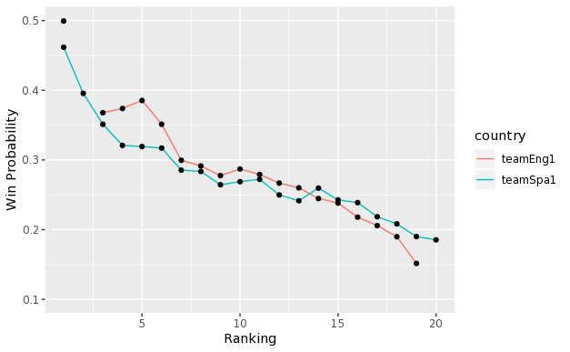

```r
readydata1 %>% # create a graph to compare winning probability for teams in England and Spain if they play against each other one by one.
  ggplot(aes(x = num, y = winprob)) +
  geom_line() +
  geom_point(color = "black") +
  aes(color = country) +
  xlab("Ranking") +
  ylim(0.1, 0.5) +
  ylab("Win Probability")
```

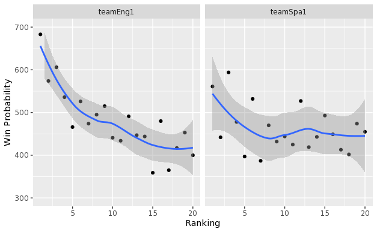

```r
readydata2 %>% # create a graph to analyze the teams' attack characteristics in England and Spain
  ggplot(aes(x = num, y= shots)) +
  geom_point() +
  geom_smooth() +
  facet_wrap(~ country) +
  xlab("Ranking") +
  ylim(300, 700)+
  ylab("Win Probability")
```

```r
# Analysis for graphs are in the next part.
```

### Describe observations and intuition about the research question

Note: I assume that England teams play against Spain teams one by one. For example: England champion vs. Spain champion … England last place vs. Spain last place.

From the first plot, I find that for top ranking teams(1 to 6, top six teams in each league will have a chance to participate in European League), England teams have a higher winning probability than Spain teams. For teams in the middle, the winning probability is really close for two countries’ teams. However, for demotion area 18 to 20 (the last three teams in each league will get a demotion to the lower level league), England teams are more likely to lose. Those observations show that England top teams might beat Spain top teams, whereas opposite for demotion teams.

From the second plot, I find that England soccer teams’ total shots have a much bigger difference between top ranking teams and demotion teams. However, for Spain soccer teams, there is not much differences. Those observations also show that England top teams are more aggressive, which leads to a better chance of winning. Also, it is opposite for demotion teams.